# Microbial Informatics

## Lecture 13

Patrick D. Schloss, PhD (microbialinformatics.github.io)  
Department of Microbiology & Immunology

## Announcements

- Homework 3 is out
- Have posted some guide lines to follow for Project 1
- For this Friday, the first hour of class will be a lecture
- Read *Introduction to Statistics with R* (Chapter 6: Regression and correlation)
- Start programming discussion next Thursday!

## Review

- **Type I Error (\(\alpha\)):** Pr(detecting difference between groups) when they are drawn from the same distribution
- **Type II Error (\(\beta\)):** Pr(not detecting difference between groups) when they are drawn from different distributions
- Power (\(1-\beta\)) is dependent on:
  - Effect size
  - Number of individuals
  - Variation in data
  - \(\alpha\)
  - Statistical test

## Learning objectives

- How to compare more than two levels of a treatment
- How to comapre two treatments, each with multiple levels
- How about when the data are not normally distrubted?

## Motivation

- Does the relative abundance of *F. nucleatum* vary between healthy people and those with adenomas or carcinoms?
- Is there a difference in the weights of male and female mice when we account for their species?

## Motivation

- Does the relative abundance of *F. nucleatum* vary between healthy people and those with adenomas or carcinoms?
  - **One-way ANOVA:** You have multiple groups or levels of a treatment and you want to know whether one of them is different
- Is there a difference in the weights of male and female mice when we account for their species?
  - **Mutliple-way ANOVA:** You have multiple treatments with multiple groups / levels and you want to know whether one of them is different
- These are really a type of regression, a topic we'll be covering over the course of the next few weeks

## Let's do an experiment...

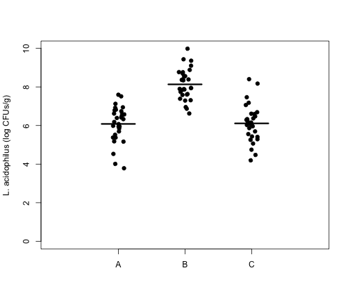

## Let's assume they all come from the same population

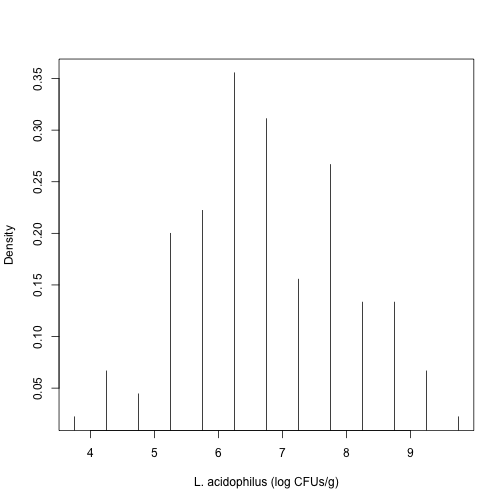

## Do they follow a normal distribution?

- Mean (\(\mu\)): 6.7752
- Standard deviation (\(\sigma\)): 1.3103

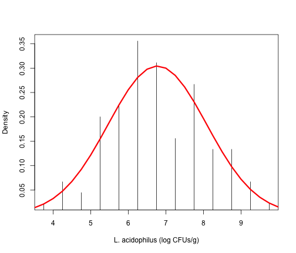

## Lets generate a model to explain the variation we see

- We can create a model to explain the observed data:

\[x_{ij}=\mu + \alpha_{i}+ \epsilon_{ij}\]

- \(x_{ij}\) is the *jth* observed value in group *i*
- \(\mu\) is the mean of all observed values (6.7752)
- \(\alpha_{i}\) is the effect size for group *i*
- \(\epsilon_{ij}\) is the error associated with the observed value
- What do you think the null hypothesis is?

## Lets generate a model to explain the variation we see

- The null hypothesis is that the effect sizes are all zero:

\[\alpha_{i} = 0\]

\[\alpha_{A} = \alpha_{B} = \alpha_{C} = 0\]

- If any of the \(\alpha\) values are not zero, then the null hypothesis should be rejected

## How do we fit the model?

- We want to partition the variation we see in the data...

\[x_{ij} = \bar{\bar x} + (\bar x_i - \bar{\bar x}) + (x_{ij} - \bar x_i)\]

- This says that the value we observed in treatment *i* is the sum of the overall mean across all data plus the *variation* due to the treatment plus the *variation* due to random noise.

## How do we fit the model?

- The total variation in the data, the Sum Squared Difference is:

\[SSD_{total} = \sum(x_{ij} - \bar x)^2\]

- The question posed by the model then is can we parition this total variation into factors we can explain, such as the three treatment groups
  - Variation between treatments
  - Unexplained variation / variation within treatments
- Which source of variation is bigger? (what does that mean?)

## How do we fit the model?

\[x_{ij} = \bar{\bar x} + (\bar x_i - \bar{\bar x}) + (x_{ij} - \bar x_i)\]

- The terms in parentheses can be collapsed into sums of variation:

\[SSD_{between} = \sum n_i (\bar x_i - \bar{\bar x})^2\] \[SSD_{within} = \sum \sum (x_{ij} - \bar x_i)^2\] \[SSD_{total} = \sum \sum (x_ij - \bar{\bar x})^2\]

## Mean squared error

- The \(SSD_{between}\) and \(SSD_{within}\) will both explain some fraction of the total variance, but we need to normalize that variance for the degrees of freedom
  - \(df_{total}\): N-1
  - \(df_{between}\): K-1
  - \(df_{within}\): N-K
- This gives us the following mean square error terms: \[MS_{between} = SSD_{between} / (K-1)\] \[MS_{within} = SSD_{within} / (N-K)\]

## How to test the significance of the differences in MS values:

\[F=MS_{between}/MS_{within}\]

- *F* > 1 indicate there is more variation between groups than within groups
- *F* <= 1 indicate there is as much variation or more within groups than between groups
- Can test significance of *F* using the F distribution (i.e. `pf`) with \(df_{between}\) and \(df_{within}\) degrees of freedom looking for values above the 95th percentile for significance

## Let's run the numbers

```r
x.doublebar <- mean(c(a, b, c))
x.bar <- apply(cbind(a,b,c), 2, mean)
n.i <- apply(cbind(a,b,c), 2, length)

ssd.between <- sum(n.i*(x.bar-x.doublebar)^2)
ssd.within <- sum((rbind(a,b,c)-x.bar)^2)
ssd.total <- sum((c(a,b,c)-x.doublebar)^2)
df.between <- 3-1
df.within <- length(c(a,b,c))-3
ms.between <- ssd.between / df.between
ms.within <- ssd.within / df.within
F <- ms.between / ms.within
P <- 1-pf(F, df.between, df.within)
```

We get an F statistic of 51.6547 with 2 and 87 degrees of freedom and a P-value of 1.5543 × 10<sup>-15</sup>.

## An easier way?

- R has many many options for performing model fits with all sorts of complexities. We first need to get our data into a single vector with another vector to annotate which group each datum belongs to:

```r
groups <- c(rep("A", length(a)), rep("B", length(b)), rep("C", length(c)))
data <- c(a, b, c)
```

## An easier way?

- We can then model the data using the `lm` command (think: linear model):

```r
anova(lm(data~groups))
```

```
## Analysis of Variance Table
##
## Response: data
##           Df Sum Sq Mean Sq F value  Pr(>F)
## groups     2   83.0    41.5    51.6 1.6e-15 ***
## Residuals 87   69.9     0.8
## ---
## Signif. codes:  0 '***' 0.001 '**' 0.01 '*' 0.05 '.' 0.1 ' ' 1
```

- Earlier we had an F statistic of 51.6547 with 2 and 87 degrees of freedom and a P-value of 1.5543 × 10<sup>-15</sup>.

## Recall our null hypothesis?

\[\alpha_{A} = \alpha_{B} = \alpha_{C} = 0\]

## So you get back a small p-value, what does that mean?

- Tests of comparisons
  - Planned comparisons <- orthoganal comparisons, a priori hypotheses
  - Unplanned comparisons <- tukey's hsd, post hoc analyses
  - All possible comparisons <- what's wrong with this approach?
- Strategy:
  - Do all possible T-tests between levels of your treatment
  - Correct alpha for multiple comparisons (e.g. Bonferroni)

## So which \(\alpha\) is significantly different?

```r
pairwise.t.test(data, groups)
```

```
##
##  Pairwise comparisons using t tests with pooled SD
##
## data:  data and groups
##
##   A       B
## B 2.6e-13 -
## C 0.9     3.0e-13
##
## P value adjustment method: holm
```

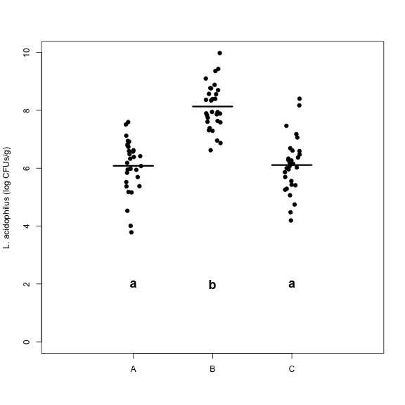

## Non-parametric test: Kruskal-Wallis Rank Sum Test

```r
kruskal.test(x=data, g=factor(groups))
```

```
##
##  Kruskal-Wallis rank sum test
##
## data:  data and factor(groups)
## Kruskal-Wallis chi-squared = 50.23, df = 2, p-value = 1.236e-11
```

## Two-way ANOVA

- Model with replication allows you to look at interactions

\[x_{ijk} = \mu + \alpha_i + \beta_j + \alpha\beta_{ij} + \epsilon_{ijk}\]

- Model without replication prevents you from looking at interactions

\[x_{ijk} = \mu + \alpha_i + \beta_j + \epsilon_{ij}\]

- Calculations get tricky if you have an unbalanced design
- Results get tricky if interaction term is significant

## An example: Without the interaction term

```r
metadata <- read.table(file="wild.metadata.txt", header=T, row.names=1)
anova(lm(metadata$Weight~metadata$SP+metadata$Sex))
```

```
## Analysis of Variance Table
##
## Response: metadata$Weight
##               Df Sum Sq Mean Sq F value Pr(>F)
## metadata$SP    1     18    17.9    0.99   0.32
## metadata$Sex   1     39    38.7    2.13   0.15
## Residuals    108   1964    18.2
```

## An example: With the interaction term

```r
anova(lm(metadata$Weight~metadata$SP*metadata$Sex))
```

```
## Analysis of Variance Table
##
## Response: metadata$Weight
##                           Df Sum Sq Mean Sq F value Pr(>F)
## metadata$SP                1     18    17.9    0.98   0.33
## metadata$Sex               1     39    38.7    2.11   0.15
## metadata$SP:metadata$Sex   1      0     0.2    0.01   0.92
## Residuals                107   1964    18.4
```

## Power

```r
between <- var(c(a.mean, b.mean, c.mean))
within <- mean(c(var(a), var(b), var(c)))
power.anova.test(groups = 3, n = 30, between.var = between, within.var = within,
    sig.level = 0.05)
```

```
##
##      Balanced one-way analysis of variance power calculation
##
##          groups = 3
##               n = 30
##     between.var = 1.383
##      within.var = 0.8029
##       sig.level = 0.05
##           power = 1
##
## NOTE: n is number in each group
```

## Power

```r
between <- var(c(6, 6, 6.5))
power.anova.test(groups = 3, n = NULL, between.var = between, within.var = within,
    power = 0.8, sig.level = 0.05)
```

```
##
##      Balanced one-way analysis of variance power calculation
##
##          groups = 3
##               n = 47.43
##     between.var = 0.08333
##      within.var = 0.8029
##       sig.level = 0.05
##           power = 0.8
##
## NOTE: n is number in each group
```